# Event Driven Hide and Seek - Exploring MCTS algorithms

### Outline

In this notebook, we will construct a simple model known as "event driven hide and seek."

- In the model, there will be an attacker and a defender on a two dimensional grid.
- The agents face an opportunity to move according to an exogenous rate.
- When it is a player's turn to move, they choose a direction to move.
- The seeker receives a reward if he catches the seeker. The seeker receives a negative (discounted) reward when he is caught. To keep things simple, this is a zero sum game.
- There is discounting
- The game ends if the attacker catches the seeker.
- We will model this as a "fully observable Event-Driven Game" (to be defined below). Intuitively, this means that the seeker knows the location of the hider and vice versa.
- There is no noise element in this game.

### Specifics

Let $W$ be an $N\times N$ grid. Let $\mathbf{L}$ be the set $\{1,2,3...N\}$

Let $V_h$ and $V_s$ be SFTs representing the hider and the seeker, respectively.

Let $S_v = (\mathbf{L}\times \mathbf{L})^2$ for $v=V_h, V_s$. Intuitively, the state of an SFT is its location on the grid and the location of the opponent.

Let $\lambda_{h}, \lambda_s$ be the rate of spontaneous events for each SFT. More formally, there is a $\lambda$ for each element of the state of the SFT. Here we assume $\lambda$ is constant across states, but not necessarily the same for the hider and seeker.

The message space $M_v$ for $v= V_h, V_s$ is also $\mathbf{L}\times \mathbf{L}$. In other words, the SFTs broadcast their location.

$\lambda_m=\infty$ for all $m\in M_v$. Messages traverse edges instantaneously.

$U_h= - e^{-\gamma t^*}$

and

$U_s= e^{-\gamma t^*}$,

where $\gamma$ is a discount rate and $t^* = \min_t(S_h(t) = S_s(t))$. There is only one reward and it occurs when the seeker finds the hider.

The agents must set $\pi_sp(\mathcal{Y}' s' |s)$ under the restriction that the only element of the state they can change is their location, their state can only change by moving at most one square and whenever they move, they transmit a message to their opponent.

This is only a rough mathematical sketch. However, we call this game "fully observable" in the sense that there exists a one-to-one mapping between the state of the agents and the state of the system as a whole. That is, an agent can observe his internal state and know exactly the state of the system.

```python
#Parameters
import numpy as np
import sys
sys.setrecursionlimit(100000)
from matplotlib import pyplot as plt
import time
from adsy.display import extended_styles
import copy
%matplotlib inline

class Player(object):
    """
    Either hider or seeker

    Tables are indexed by [hider loc, seeker_loc]
    """
    def __init__(self, rate, s0, name):
        self.rate=rate
        self.loc=s0 # Just the location
        self.name=name

    def create_value_and_counts(self, N):
        self.values = np.zeros((N,N,N,N,5))
        self.counts = np.zeros((N,N,N,N,5))

    def newstate(self, hider_loc, seeker_loc, updatevisits = True):
        visits = np.sum(self.counts[hider_loc[0], hider_loc[1], seeker_loc[0], seeker_loc[1], :])
        if visits > 0:
            return False
        else:
            if updatevisits:
                self.counts[hider_loc[0], hider_loc[1], seeker_loc[0], seeker_loc[1], :] +=1
            return True


class FullyObservableHideandSeek(object):
    """
    Last dimension of p1_dist corresponds to North East South West Stay
    """
    def __init__(self, hider, seeker, N, gamma=.5, c=2):
        self.N = N
        self.hider = hider
        self.seeker=seeker
        self.hider.create_value_and_counts(self.N)
        self.seeker.create_value_and_counts(self.N)
        self.event_pdf = [self.seeker.rate/float(self.seeker.rate +self.hider.rate),
                          self.hider.rate/float(self.seeker.rate +self.hider.rate)]
        self.gamma = gamma
        self.c = c
        self.calls = 0
        self.optactions = []

    def do_maxn(self, numreps, resetstate_hider=None, resetstate_seeker = [0,0]):
        if resetstate_hider is None:
            resetstate_hider = [self.N-1, self.N-1]
        self.res = []
        self.time = []
        for rep in range(numreps):
            self.maxn_simulate()
            self.res.append(max(self.seeker.values[self.N-1, self.N-1, 0,0,:]))
            self.hider.loc = [self.N-1, self.N -1]
            self.seeker.loc = [0,0]
            self.time.append(time.time())
            self.optactions.append(np.argmax(self.seeker.values[self.N-1, self.N-1, 0,0,:]))

        return None

    def maxn_simulate(self,  t=0, game_over=False, player=None, nested_mcts=False):
        """
        Player is a player instance
        """
        q=np.array([0,0]) # Seeker and hider
        if game_over:
            return np.array([0,0])
        act_player = np.random.choice([self.seeker, self.hider], p = self.event_pdf)
        t += np.random.exponential(1/np.sum(np.asarray(self.event_pdf)))
        if act_player.newstate(self.hider.loc, self.seeker.loc):
            return self.rollout(act_player, t)
        move_row_val = act_player.values[self.hider.loc[0], self.hider.loc[1], self.seeker.loc[0], self.seeker.loc[1], :]
        move_row_cts = act_player.counts[self.hider.loc[0], self.hider.loc[1], self.seeker.loc[0], self.seeker.loc[1], :]
        move_ix = np.argmax(move_row_val + self.c *(np.log(np.sum(move_row_cts)) / np.float_(move_row_cts))**.5)
        move = ['N', 'E', 'S', 'W', 'P'][move_ix]
        self.update_state(act_player, move)
        game_over = self.hider.loc == self.seeker.loc
        move_row_cts[move_ix] += 1
        r = self.reward() + np.exp(-self.gamma*t)* self.maxn_simulate(t, game_over)
        if act_player.name=='seeker':
            move_row_val[move_ix] += (r[0] - move_row_val[move_ix])/move_row_cts[move_ix]
        else:
            move_row_val[move_ix] += (r[1] - move_row_val[move_ix])/move_row_cts[move_ix]
        return r

    def rollout(self, player, t):
        is_valid = False
        while not is_valid:
            move = np.random.choice(('N', 'E', 'S', 'W', 'P')) #P for pass aka do notihng
            is_valid = self.eligible_move(player.loc, move)
        self.update_state(player, move)
        game_over = self.hider.loc == self.seeker.loc
        r = self.reward()
        return r + np.exp(-self.gamma * t) * self.maxn_simulate(game_over=game_over, t=t)

    def update_state(self, player, move):
        if (move == 'N') and (player.loc[1] > 0):
            player.loc[1] -=1
        if (move == 'S') and (player.loc[1] < self.N-1):
            player.loc[1] +=1
        if (move == 'E') and (player.loc[0] < self.N-1):
            player.loc[0] +=1
        if (move == 'W') and (player.loc[0] > 0):
            player.loc[0] -=1

    def reward(self):
        """
        Assign large negative rewards for going off grid
        """
        if self.seeker.loc == self.hider.loc:
            return np.array([1, -1])
        #elif self.seeker.loc ==[3,2]:
        #    return np.array([-10, 0])
        #elif self.seeker.loc==[2,2]:
        #    return np.array([-10, 0])
        else:
            return np.array([0,0])

    def eligible_move(self, loc, move):
        if (loc[0]==0) and (move=='W'):
            return False
        elif (loc[0]==self.N-1) and (move =='E'):
            return False
        elif (loc[1] ==0) and (move =='N'):
            return False
        elif (loc[1]==self.N-1) and (move =='S'):
            return False
        else:
            return True

    def do_nested_mcts(self, player, hiderstate, seekerstate, numsims = 1, gameover=False, initial=False, t=0):
        """
        Finds the optimal action for a player
        whose turn it is to move.  State is given by current
        state of hider and seeker
        """
        #print 'entering'
        if seekerstate == [0,0]:
            self.calls += 1
        if initial:
            self.res = []
            self.time = []
        if gameover:
            return 'P'
        self.hider.loc=copy.copy(hiderstate)
        self.seeker.loc=copy.copy(seekerstate)
        for j in range(numsims):
            self.nested_simulate(self.hider.loc, self.seeker.loc, player, t=t ,numsims=numsims)
            self.hider.loc = copy.copy(hiderstate)
            self.seeker.loc = copy.copy(seekerstate)
            self.res.append(max(self.seeker.values[self.N-1, self.N-1, 0,0,:]))
            self.time.append(time.time())
            self.optactions.append(np.argmax(self.seeker.values[self.N-1, self.N-1, 0,0,:]))

        ix = np.argmax(player.values[hiderstate[0], hiderstate[1],seekerstate[0], seekerstate[1], :])
        return ['N', 'E', 'S', 'W', 'P'][ix]

    def nested_simulate(self, hiderstate, seekerstate, player, gameover=False, t=0, numsims=1):
        act_player = player
        starting = copy.copy(seekerstate)
        if act_player.newstate(self.hider.loc, self.seeker.loc):
            move = self.nested_rollout(act_player)
            move_row_val = act_player.values[self.hider.loc[0], self.hider.loc[1], self.seeker.loc[0], self.seeker.loc[1], :]
            move_row_cts = act_player.counts[self.hider.loc[0], self.hider.loc[1], self.seeker.loc[0], self.seeker.loc[1], :]
            move_ix = ['N', 'E', 'S', 'W', 'P'].index(move)
        else:
            move_row_val = act_player.values[self.hider.loc[0], self.hider.loc[1], self.seeker.loc[0], self.seeker.loc[1], :]
            move_row_cts = act_player.counts[self.hider.loc[0], self.hider.loc[1], self.seeker.loc[0], self.seeker.loc[1], :]
            move_ix = np.argmax(move_row_val + self.c *(np.log(np.sum(move_row_cts)) / np.float_(move_row_cts))**.5)
            move = ['N', 'E', 'S', 'W', 'P'][move_ix]
        self.update_state(act_player, move)
        gameover = self.hider.loc == self.seeker.loc
        move_row_cts[move_ix] += 1
        if act_player.name=='seeker':
            r= self.reward()[0]
        else:
            r=self.reward()[1]
        while not gameover:
            newplayer = np.random.choice([self.seeker, self.hider], p = self.event_pdf)
            t += np.random.exponential(1/np.sum(np.asarray(self.event_pdf)))
            move = self.do_nested_mcts(newplayer, copy.copy(self.hider.loc), copy.copy(self.seeker.loc),
                                       gameover=gameover, numsims=numsims)
            self.update_state(newplayer, move)
            gameover = self.hider.loc == self.seeker.loc
            #move_row_cts[move_ix] += 1
            if act_player.name=='seeker':
                r += np.exp(-self.gamma *t) * self.reward()[0]
                #print r, self.seeker.loc
                #r += self.reward()[0]
            else:
                r += self.reward()[1]
        move_row_val[move_ix] += (r - move_row_val[move_ix])/float(move_row_cts[move_ix])

    def nested_rollout(self, player):
        is_valid = False
        while not is_valid:
            move = np.random.choice(('N', 'E', 'S', 'W', 'P')) #P for pass aka do notihng
            is_valid = self.eligible_move(player.loc, move)
        return move
```

```python
extended_styles()
```

# Experiment Set 1 - Max-N vs Nature (Traditional MCTS)

```python
hider = Player(0, [3, 3], 'hider')
seeker = Player(1, [0,0], 'seeker')
Game = FullyObservableHideandSeek(hider, seeker, N=4, gamma=.1, c=1.5)
Game.do_maxn(10000)
```

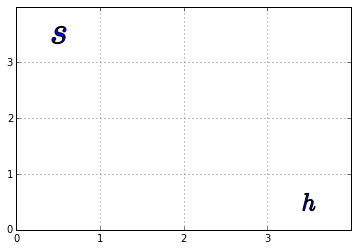

```python
fig, ax = plt.subplots()
ax.set_xlim(0,4)
ax.set_ylim(0,4)
ax.set_xticks(np.arange(0,4,1))
ax.set_yticks(np.arange(0,4,1))
ax.scatter(.5, 3.5, s=300, marker=r"$ {} $".format('s'))
ax.scatter(3.5, .5, s=300, marker =r"$ {} $".format('h'))
plt.grid(True)
print
```

#### Experiment 1.1.1 - Clock time until convergence

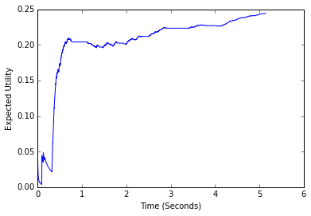

```python
fig, ax =plt.subplots()
ax.plot(np.asarray(Game.time) - Game.time[0], Game.res)
ax.set_xlabel('Time (Seconds)')
ax.set_ylabel('Expected Utility')
print
```

#### Experiment 1.1.2 - Optimal first action and simulation time

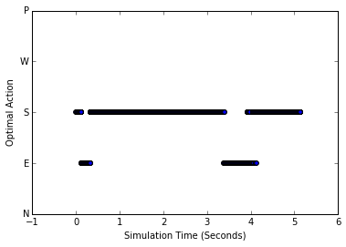

```python
fig, ax = plt.subplots()
ax.scatter(np.asarray(Game.time)-Game.time[0], Game.optactions)
ax.set_yticks(np.arange(0,5,1))
ax.set_yticklabels(['N', 'E', 'S', 'W', 'P'])
ax.set_ylabel('Optimal Action')
ax.set_xlabel('Simulation Time (Seconds)')
print
```

### Experiment 1.2 - Same as experiment 1 with lower $c$ parameter

```python
hider = Player(0, [3, 3], 'hider')
seeker = Player(1, [0,0], 'seeker')
Game2 = FullyObservableHideandSeek(hider, seeker, N=4, gamma=.1, c=.1)
Game2.do_maxn(60000)
print
```

#### Experiment 1.2.1 - Clock time until convergence

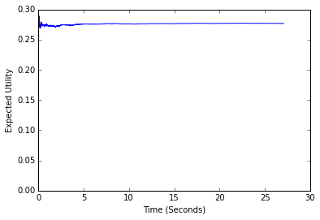

```python
fig, ax =plt.subplots()
ax.plot(np.asarray(Game2.time) - Game2.time[0], Game2.res)
ax.set_xlabel('Time (Seconds)')
ax.set_ylabel('Expected Utility')
print
```

#### Experiment 1.2.2 - Optimal First Action

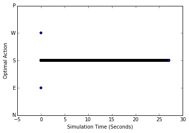

```python
fig, ax = plt.subplots()
ax.scatter(np.asarray(Game2.time)-Game2.time[0], Game2.optactions)
ax.set_yticks(np.arange(0,5,1))
ax.set_yticklabels(['N', 'E', 'S', 'W', 'P'])
ax.set_ylabel('Optimal Action')
ax.set_xlabel('Simulation Time (Seconds)')
print
```

### Illustration 1.1 Optimal Policy

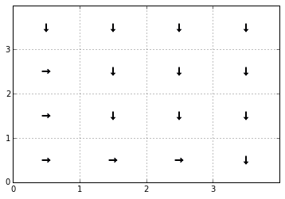

```python
pol = []
for i in range(4):
    for j in range(4):
        pol.append((i,j, np.argmax(Game.seeker.values[3,3,i,j,:])))
fig, ax = plt.subplots()
for p in pol:
    if p[2] == 2:
        symbol = ur'$\u2193$'
    elif p[2] ==1:
        symbol = ur'$\u2192$'
    elif p[2]==3:
        symbol = ur'$\u2190$'
        color='r'
    ax.scatter(p[0]+.5, 3-p[1]+.5, marker=symbol, s=100)

plt.grid(True)
ax.set_xlim(0,4)
ax.set_ylim(0,4)
ax.set_xticks(np.arange(0,4,1))
ax.set_yticks(np.arange(0,4,1))
print
```

## Experiment 1.3 Same but on a larger Grid

```python
hider = Player(0, [9, 9], 'hider')
seeker = Player(3, [0,0], 'seeker')
Game_big = FullyObservableHideandSeek(hider, seeker, gamma=.1, c=.1, N=10)
Game_big.do_maxn(5000)
```

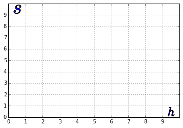

```python
fig, ax = plt.subplots()
ax.set_xlim(0,10)
ax.set_ylim(0,10)
ax.set_xticks(np.arange(0,10,1))
ax.set_yticks(np.arange(0,10,1))
ax.scatter(.5, 9.5, s=300, marker=r"$ {} $".format('s'))
ax.scatter(9.5, .5, s=300, marker =r"$ {} $".format('h'))
plt.grid(True)
print
```

### Experiment 1.3.1-Clock time until convergence

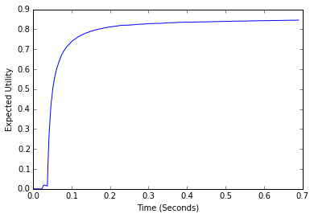

```python
fig, ax =plt.subplots()
ax.plot(np.asarray(Game_big.time) - Game_big.time[0], Game_big.res)
ax.set_xlabel('Time (Seconds)')
ax.set_ylabel('Expected Utility')
print
```

## Illustration 1.2 Optimal Policy

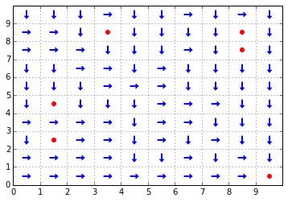

```python
pol = []
for i in range(10):
    for j in range(10):
        pol.append((i,j, np.argmax(Game_big.seeker.values[9,9,i,j,:])))
fig, ax = plt.subplots()
for p in pol:
    if p[2] == 2:
        symbol = ur'$\u2193$'
        color='b'
    elif p[2]==1:
        symbol = ur'$\u2192$'
        color='b'
    else:
        symbol = '.'
        color='r'
    ax.scatter(p[0]+.5, 9-p[1]+.5, marker=symbol, s=100, color=color)

plt.grid(True)
ax.set_xlim(0,10)
ax.set_ylim(0,10)
ax.set_xticks(np.arange(0,10,1))
ax.set_yticks(np.arange(0,10,1))
print
```

# Experiment Set 2 - Nested MCTS vs Nature

```python
hider = Player(0, [3, 3],  'hider')
seeker = Player(1, [0,0], 'seeker')
Game_nested = FullyObservableHideandSeek(hider, seeker, 4, gamma=.1, c=.2)
#Game_nested.seeker.loc
Game_nested.do_nested_mcts(Game_nested.seeker, Game_nested.hider.loc, Game_nested.seeker.loc, numsims=100, initial=True)
```

```
'E'
```

#### Experiment 2.1.1 - Clock time until convergence

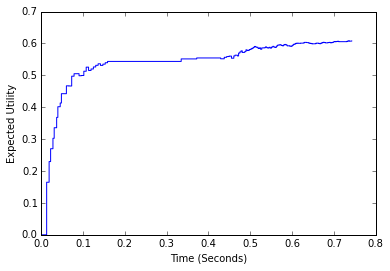

```python
fig, ax =plt.subplots()
ax.plot(np.asarray(Game_nested.time) - Game_nested.time[0], Game_nested.res)
ax.set_xlabel('Time (Seconds)')
ax.set_ylabel('Expected Utility')
print
```

#### Experiment 2.1.2 - Optimal First Action

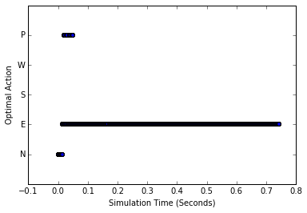

```python
fig, ax = plt.subplots()
ax.scatter(np.asarray(Game_nested.time)-Game_nested.time[0], Game_nested.optactions)
ax.set_yticks(np.arange(0,5,1))
ax.set_yticklabels(['N', 'E', 'S', 'W', 'P'])
ax.set_ylabel('Optimal Action')
ax.set_xlabel('Simulation Time (Seconds)')
print
```

## Illustration 2.1 Optimal Policy

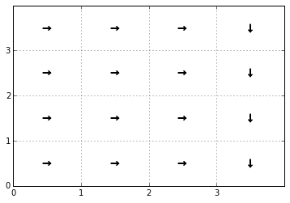

```python
pol = []
for i in range(4):
    for j in range(4):
        pol.append((i,j, np.argmax(Game_nested.seeker.values[3,3,i,j,:])))
fig, ax = plt.subplots()
for p in pol:
    if p[2] == 2:
        symbol = ur'$\u2193$'
    elif p[2] ==1:
        symbol = ur'$\u2192$'
    elif p[2]==3:
        symbol = ur'$\u2190$'
        color='r'
    ax.scatter(p[0]+.5, 3-p[1]+.5, marker=symbol, s=100)

plt.grid(True)
ax.set_xlim(0,4)
ax.set_ylim(0,4)
ax.set_xticks(np.arange(0,4,1))
ax.set_yticks(np.arange(0,4,1))
print
```

## Experiments 2.2 -Larger Grid

Nested MCTS, in it's simplest form cannot handle a 10X10 grid! The reason is that the MCTS runs until the end of the game, the only time rewards are accumulated. However, since it does not know where the reward cell is, it basically moves randomly until it finds the cell. Everytime there is a move, however it enters another nested MCTS.

```python
#%%timeit -r1 -n1
start = time.time()
hider = Player(0, [6, 6], 'hider')
seeker = Player(1, [0,0], 'seeker')
Game_nested_big = FullyObservableHideandSeek(hider, seeker, gamma=.1, c=.2, N=7)
Game_nested_big.do_nested_mcts(Game_nested_big.seeker, Game_nested_big.hider.loc,
                               Game_nested_big.seeker.loc, numsims=1, initial=True)
print 'This run took, ', time.time()-start
```

```
This run took,  146.581885099
```

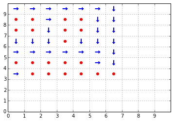

```python
pol = []
for i in range(7):
    for j in range(7):
        pol.append((i,j, np.argmax(Game_nested_big.seeker.values[6,6,i,j,:])))
fig, ax = plt.subplots()
for p in pol:
    if p[2] == 2:
        symbol = ur'$\u2193$'
        color='b'
    elif p[2]==1:
        symbol = ur'$\u2192$'
        color='b'
    else:
        symbol = '.'
        color='r'
    ax.scatter(p[0]+.5, 9-p[1]+.5, marker=symbol, s=100, color=color)

plt.grid(True)
ax.set_xlim(0,10)
ax.set_ylim(0,10)
ax.set_xticks(np.arange(0,10,1))
ax.set_yticks(np.arange(0,10,1))
print
```

Campare the accuracy and time with a max-n on the same grid:

```python
start = time.time()
hider = Player(0, [6, 6], 'hider')
seeker = Player(3, [0,0], 'seeker')
Game_big2 = FullyObservableHideandSeek(hider, seeker, gamma=.1, c=.05, N=7)
Game_big2.do_maxn(3000)
print 'This run took, ', time.time()-start
```

```
This run took,  17.7467370033
```

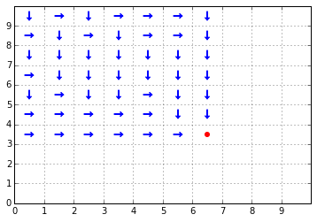

```python
pol = []
for i in range(7):
    for j in range(7):
        pol.append((i,j, np.argmax(Game_big2.seeker.values[6,6,i,j,:])))
fig, ax = plt.subplots()
for p in pol:
    if p[2] == 2:
        symbol = ur'$\u2193$'
        color='b'
    elif p[2]==1:
        symbol = ur'$\u2192$'
        color='b'
    else:
        symbol = '.'
        color='r'
    ax.scatter(p[0]+.5, 9-p[1]+.5, marker=symbol, s=100, color=color)

plt.grid(True)
ax.set_xlim(0,10)
ax.set_ylim(0,10)
ax.set_xticks(np.arange(0,10,1))
ax.set_yticks(np.arange(0,10,1))
print
```

# General Comments

- Nested MCTS is "less controllable"
  - Suppose we want to do MCTS for player $j$ in state $s$. Suppse we specify the outer loop to do UCT 10 times
  - However, the number of times we will actually do UCT from state $s$ for player $j$ is 10 times the number of times we revisit state $j$. This can lead to a lot of unnecessary looping.
  - Of course we can hand code in rules (for example, if a state has been visited more than a certain number of times, avoid doing MCTS and simply choose the action with the highest utility.
  - However, thos will not work in aprtially observable games as the underlying state of the world might be different
- Nested MCTS grows multiplicatively with the depth, UCT grows additively. In other words, increasing the depth by 1 in MAX-N only adds one extra call to UCT. Increasing the MCTS depth by 1 adds another call to MCTS, which is results in numerous calls to UCT.
  - Nested MCTS had trouble with relatively small depths.
  - Nested MCTS will not be able to handle scenarios where substantial rewards are accumulated relatively far in the future.
- Nested MCTS will be inefficient for determining the optimal move that seeds the MCTS. For each move that it tries, nested MCTS will have a more accurate expected utility for each possible action, however it will waste a lot of time on actions that do not yield the highest expected utility. In RL language, this is making the explore much more expensive when the unit of account is exploiting.
- Other nested MCTS questions:
  - How do we set the depth for player's "down the line." Do we linearly decrease the depth? and if so, why?

## Experiment set 3 - Two Player Max-N

```python
start = time.time()
hider = Player(1., [3, 3], 'hider')
seeker = Player(1., [0,0], 'seeker')
twoplayer_Game = FullyObservableHideandSeek(hider, seeker, N=4, gamma=.1, c=.3)
twoplayer_Game.do_maxn(20000)
print 'Experiment took', time.time()-start
```

```
Experiment took 28.3248238564
```

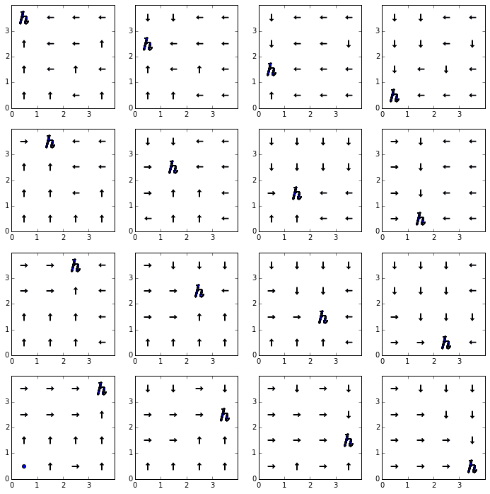

```python
fig, axs = plt.subplots(4,4)
fig.set_size_inches(12,12)
for k in range(4):
    for l in range(4):
        pol = []
        for i in range(4):
            for j in range(4):
                pol.append((i,j, np.argmax(twoplayer_Game.seeker.values[k,l,i,j,:])))
        #print 'newplot'
        for p in pol:
            if p[2] == 2:
                symbol = ur'$\u2193$'
            elif p[2] ==1:
                symbol = ur'$\u2192$'
            elif p[2]==3:
                symbol = ur'$\u2190$'
            elif p[2]==0:
                symbol = ur'$\u2191$'
            else:
                symbol = '.'
            if not ((p[0]==k) and( p[1]==l)):
                axs[k,l].scatter(p[0]+.5, 3-p[1]+.5, marker=symbol, s=100)
            axs[k,l].scatter(k +.5, 3-l+.5, s=300, marker =r"$ {} $".format('h'))
        #plt.grid(True)
        axs[k,l].set_xlim(0,4)
        axs[k,l].set_ylim(0,4)
        axs[k,l].set_xticks(np.arange(0,4,1))
        axs[k,l].set_yticks(np.arange(0,4,1))
```

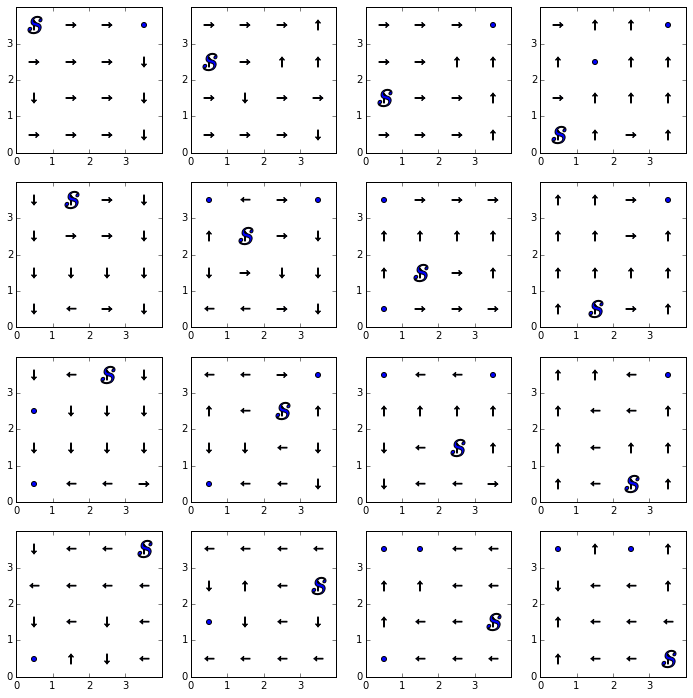

```python
fig, axs = plt.subplots(4,4)
fig.set_size_inches(12,12)
for k in range(4):
    for l in range(4):
        pol = []
        for i in range(4):
            for j in range(4):
                pol.append((i,j, np.argmax(twoplayer_Game.hider.values[i,j,k,l,:])))
        #print 'newplot'
        for p in pol:
            if p[2] == 2:
                symbol = ur'$\u2193$'
            elif p[2] ==1:
                symbol = ur'$\u2192$'
            elif p[2]==3:
                symbol = ur'$\u2190$'
            elif p[2]==0:
                symbol = ur'$\u2191$'
            else:
                symbol = '.'
            #if not ((p[0]==k) and( p[1]==l)):
            axs[k,l].scatter(p[0]+.5, 3-p[1]+.5, marker=symbol, s=100)
        axs[k,l].scatter(k +.5, 3-l+.5, s=300, marker =r"$ {} $".format('s'))
        #plt.grid(True)
        axs[k,l].set_xlim(0,4)
        axs[k,l].set_ylim(0,4)
        axs[k,l].set_xticks(np.arange(0,4,1))
        axs[k,l].set_yticks(np.arange(0,4,1))
```

## Experiments 3.2 - Two player nested MCTS?

```python
start = time.time()
hider = Player(1, [2, 2], 'hider')
seeker = Player(1, [0,0], 'seeker')
twoplayer_Game_nested = FullyObservableHideandSeek(hider, seeker, N=3, gamma=.1, c=.25)
#twoplayer_Game_nested.do_nested_mcts(twoplayer_Game_nested.seeker, twoplayer_Game_nested.hider.loc,
#                               twoplayer_Game_nested.seeker.loc, numsims=2, initial=True)
```

Crashes Machine!

# And now for something completely different

Before running the level-k experiments, I am still trying to build some "confidence" in the MCTS algorithm. We have already looked at some seemingly plausible examples :

http://j-grana6.github.io/Notebooks/mpltest.html

Now I wanted to add one more level of confidence.

Here we have a simple straight line network (as shown below). The parameters are such that:

- Defenders window is 3 time steps
- Background message rate is .1 timestepsfor all consecutive hosts
- Attacker receives the opportunity to send a malicious message at a rate of 8 per time step (much higher than the rate of background messages).
- Attacker's memory is gridded at .1 intervals
- *The attacker in this case is only trading off advancing in the network vs waiting. He does not need to choose the correct path*

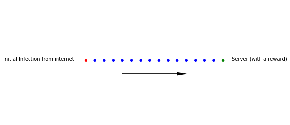

```python
fig, ax = plt.subplots()
ax.scatter( np.arange(0,16),[5]*len(np.arange(0,16)), color = ['red'] + ['blue']*14 + ['green'])
ax.text(-9, 5, 'Initial Infection from internet')
ax.text(16, 5, 'Server (with a reward)')
ax.arrow(4, 4.9975, 6, 0, head_width=0.0005, head_length=1, width=.00005, color='black')
ax.axis('off')
print
```

## Algorithm Notes - Just-in-Time MCTS

- It is impossible to solve for an optimal policy
  - Too many states when the attacker's memory is so fine grained
- Instead, we simulate the system as a stochastic process. When we get to an attacker's move, he performs MCTS to choose his action. One run (either until the attacker reaches the server or the alarm sounds) will consist of the attacker doing MCTS multiple times, choosing either to advance in the network or to wait.
- Need to come up with a clever way to reuse information from previous runs (Memory Issues due to the particle filter)

```python
eulist=[0, 0, 0, 0, 0, 0, 0, 0, 0, 0, 1, 1, 0, 1, 1, 1, 0, 1, 0, 0, 1, 0, 1, 1, 0,
        0, 1, 1, 0, 0, 0, 0, 1, 1, 0, 1, 0, 0, 0, 0, 1, 0, 0, 1, 0, 0, 0, 0, 0, 0,
        0, 0, 0, 1, 0, 1, 0, 0, 0, 0, 0, 0, 1, 0, 0, 0, 0, 0, 0, 1, 0, 0, 1, 0, 1,
        1, 0, 1, 0, 1, 0, 0, 0, 0, 1, 0, 0, 0, 1, 1, 0, 0, 1, 1, 0, 0, 0, 0, 1, 0,
        0, 1, 0, 1, 0, 0, 0, 1, 1, 0, 0, 0, 0, 0, 0, 0, 0, 0, 0, 1, 0, 0, 0, 0, 1,
        0, 1, 1, 1, 1, 1, 0, 0, 1, 0, 1, 1, 1, 1, 0, 0, 0, 0, 0, 0, 1, 0, 0, 0, 0,
        0, 0, 0, 1, 1, 1, 0, 0, 0, 0, 1, 0, 0, 1, 0, 0, 0, 1, 0, 1, 1, 1, 0, 0, 0,
        1, 0, 0, 0, 1, 0, 1, 1, 0, 0, 0, 1, 0, 0, 0, 0, 0, 1, 1, 0, 1, 1, 1, 1, 0,
        1, 0, 1, 0, 0, 1, 1, 0, 0, 0, 0, 1, 0, 1, 1, 0, 1, 1, 1, 0, 0, 0, 0, 0, 0,
        0, 1, 0, 0, 0, 1, 0, 1, 1, 0, 0, 0, 1, 1, 0, 0, 0, 0, 0, 0, 0, 1, 0, 0, 0,
        0, 0, 1, 0, 1, 0, 0, 0, 0, 0, 0, 0, 1, 0, 1, 0, 1, 1, 0, 1, 1, 1, 1, 0, 0,
        0, 0, 1, 0, 1, 1, 0, 1, 1, 1, 0, 0, 0, 1, 0, 0, 0, 1, 0, 0, 0, 1, 1, 1, 1,
        0, 0, 1, 0, 1, 1, 1, 0, 0, 1, 1, 0, 1, 0, 0, 0, 0, 0, 1, 1, 0, 1, 0, 1, 1,
        1, 1, 0, 0, 0, 0, 1, 0, 0, 1, 0, 0, 1, 1, 0, 1, 1, 1, 1, 0, 0, 0, 0, 0, 1,
        0, 1, 1, 1, 0, 0, 1, 0, 0, 1, 0, 1, 1, 1, 1, 0, 1, 1, 0, 0,
        0, 0, 0, 0, 0, 0, 0, 0, 0, 1, 1, 1, 0, 0, 0, 0, 1, 0, 0, 1,
        1, 0, 0, 0, 0, 0, 0, 0, 0, 0, 0, 1, 0, 0, 0, 0, 0, 0, 0, 1,
        0, 1, 0, 0, 0, 0, 1, 0, 0, 1, 0, 0, 0, 0, 1, 1, 1, 0, 0, 0,
        0, 1, 0, 1, 0, 1, 0, 1, 0, 1, 1, 0, 0, 0, 0, 0, 1, 0, 0, 1,
        1, 1, 0, 0, 0, 1, 0, 0, 0, 0, 0, 1, 0, 0, 1, 0, 0, 0, 1, 0,
        0, 0, 0, 0, 0, 0, 1, 1, 0, 1, 0, 0, 0, 1, 0, 0, 0, 0, 1, 0,
        0, 0, 1, 0, 0, 0, 0, 0, 0, 1, 0, 1, 1, 1, 0, 1, 0, 0, 0, 1,
        0, 1, 0, 0, 1, 0, 1, 0, 1, 1, 0, 0, 0, 0, 0, 0, 1,
        0, 0, 0, 1, 0, 1, 0, 0, 1, 1, 1, 1, 1 ,0,
        1, 0, 0, 0, 0, 1, 0, 1, 0, 1, 0, 0, 1, 0, 1, 0, 0, 1,
        1, 0, 0, 1, 1, 0, 1, 0, 1, 0, 0, 1, 1, 1, 1,
        1, 0, 0, 1, 0, 0, 1, 1, 0, 0, 0, 0, 0, 0, 0, 0, 0, 1, 0, 1,
        0, 1, 0, 1, 0, 1, 0, 1, 1, 0, 0, 1, 0, 0, 1, 0, 0, 0, 0, 0,
        0, 0, 1, 0, 1, 0, 0, 0, 1, 1, 0, 1, 0, 1, 1, 0, 1, 1, 1, 1,
        0, 0, 1, 1, 1, 0, 1, 1, 1, 1, 0, 0, 0, 0, 1, 0, 0, 1, 0, 1,
        1, 0, 0, 0, 1, 1, 0, 1, 0, 1, 1, 0, 1, 1, 0, 0, 1, 1, 0, 0,
        0, 0, 1, 1, 0, 1, 1, 1, 0, 1, 0, 0, 0, 0, 1, 1, 0, 0, 0, 0,
        0, 0, 0, 0, 0, 1, 1,
        1 , 1, 0, 1, 0, 1, 0, 0,
        0, 0, 1,1]
```

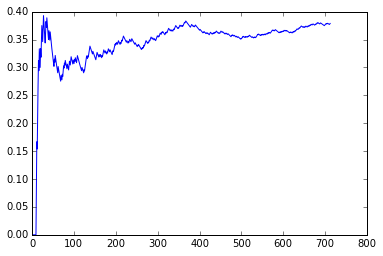

```python
plt.plot(np.cumsum(eulist)/np.float_(np.arange(1, len(eulist) +1)))
```

## Expected Utilities for Random Strategies

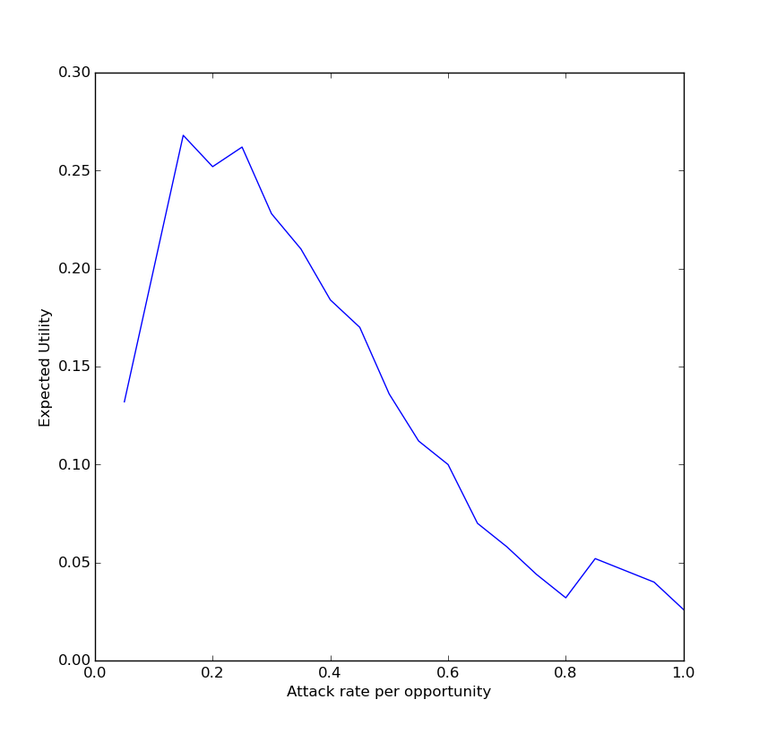

```python
from IPython.display import Image
Image('random_strats.png', width=450)
```

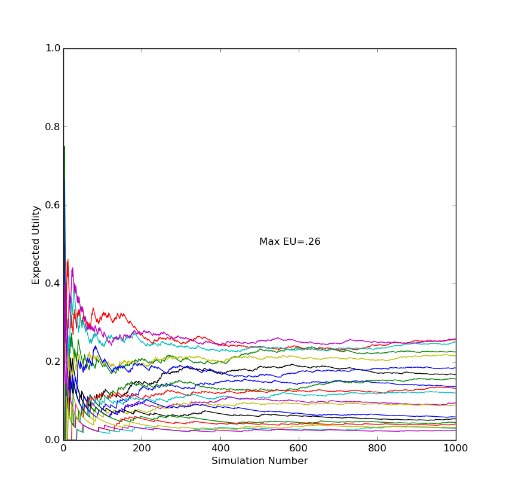

```python
from IPython.display import Image
Image('randomconverge.png', width=450)
```

```python
from statsmodels.graphics.tsaplots import plot_acf
```